# Hillstrom Email Experiment: From Randomization Checks to Qini Curves

Jiaying Zhao

This report follows the analysis in 01_data.R and 02_model.R. Code is read directly from these scripts to avoid maintaining duplicate implementations. The data come from a randomized email experiment with three arms: `No E-Mail`, `Womens E-Mail`, and `Mens E-Mail`. The primary outcome, `conversion`, indicates whether a customer purchased within two weeks after the experiment. Pretreatment features are used to assess balance and predict treatment effects; `visit` and `conversion` are post-treatment outcomes.

## 1. Load Data and Create Training and Test Sets

The split is stratified by the randomized treatment arm, `segment`, with approximately 80% allocated to training and 20% to testing. The full sample is retained to describe conversion and visit rates across all three arms. A fixed random seed makes the split reproducible.

```r
data_file <- "data/hillstrom.csv"

set.seed(12345)
d <- read.csv(data_file, stringsAsFactors = FALSE)

# train:test = 4:1

train_idx <- unlist(
  lapply(split(seq_len(nrow(d)), d$segment), function(idx){
    sample(idx, size = floor(0.8 * length(idx)))
  })
)


dtrain <- d[train_idx, ]
dtest  <- d[-train_idx, ]

d$trainIdx <- seq_len(nrow(d)) %in% train_idx

table(d$segment, d$conversion, d$visit)
```

```
## , ,  = 0
##
##
##                     0     1
##   Mens E-Mail   17413     0
##   No E-Mail     19044     0
##   Womens E-Mail 18149     0
##
## , ,  = 1
##
##
##                     0     1
##   Mens E-Mail    3627   267
##   No E-Mail      2140   122
##   Womens E-Mail  3049   189
```

```r
segs = unique(d$segment)
res <- data.frame(
  segment = segs,
  n = sapply(segs, function(s) nrow(d[d$segment==s, ])),
  purchases = sapply(segs, function(s) sum(d$conversion[d$segment==s])),
  conversion_rate = sapply(segs, function(s) mean(d$conversion[d$segment==s])),
  visit_rate = sapply(segs, function(s) mean(d$visit[d$segment==s]))
)

print(res)
```

```
##                     segment     n purchases conversion_rate visit_rate
## Womens E-Mail Womens E-Mail 21387       189     0.008837144  0.1514004
## No E-Mail         No E-Mail 21306       122     0.005726087  0.1061673
## Mens E-Mail     Mens E-Mail 21307       267     0.012531093  0.1827568
```

```r
# df |>
#   group_by(segment) |>
#   summarise(
#     n = n(),
#     purchases = sum(conversion),
#     conversion_rate = mean(conversion),
#     visit_rate = mean(visit)
#   )

library(dplyr)
d %>%
  group_by(trainIdx) %>%
  summarise(count = n())
```

```
## # A tibble: 2 × 2
##   trainIdx count
##   <lgl>    <int>
## 1 FALSE    12802
## 2 TRUE     51198
```

## 2. Check Pretreatment Covariate Balance: SMD

Each email arm is compared with the no-email control. Continuous variables are used directly, while categorical variables are represented by one indicator per category. The standardized mean difference is

$$\operatorname{SMD}(X)=
\frac{\bar X_a-\bar X_0}
{\sqrt{(s_a^2+s_0^2)/2}}.$$

The plot shows absolute SMDs. The dashed line at 0.1 is a common rule of thumb. Small SMDs indicate similarity in measured covariates; they do not establish all causal identification assumptions.

```r
num_cols <- c("recency", "history", "mens", "womens", "newbie")
cat_cols <- c("history_segment", "zip_code", "channel")
features <- c(num_cols, cat_cols)


balance <- as.matrix(d[num_cols])
for (v in cat_cols) for (level in sort(unique(d[[v]])))
  balance <- cbind(balance, setNames(data.frame(as.numeric(d[[v]] == level)), paste(v, level, sep="=")))
balance <- as.matrix(balance)

smd <- data.frame(feature=colnames(balance))



unique(d$segment)
```

```
## [1] "Womens E-Mail" "No E-Mail"     "Mens E-Mail"
```

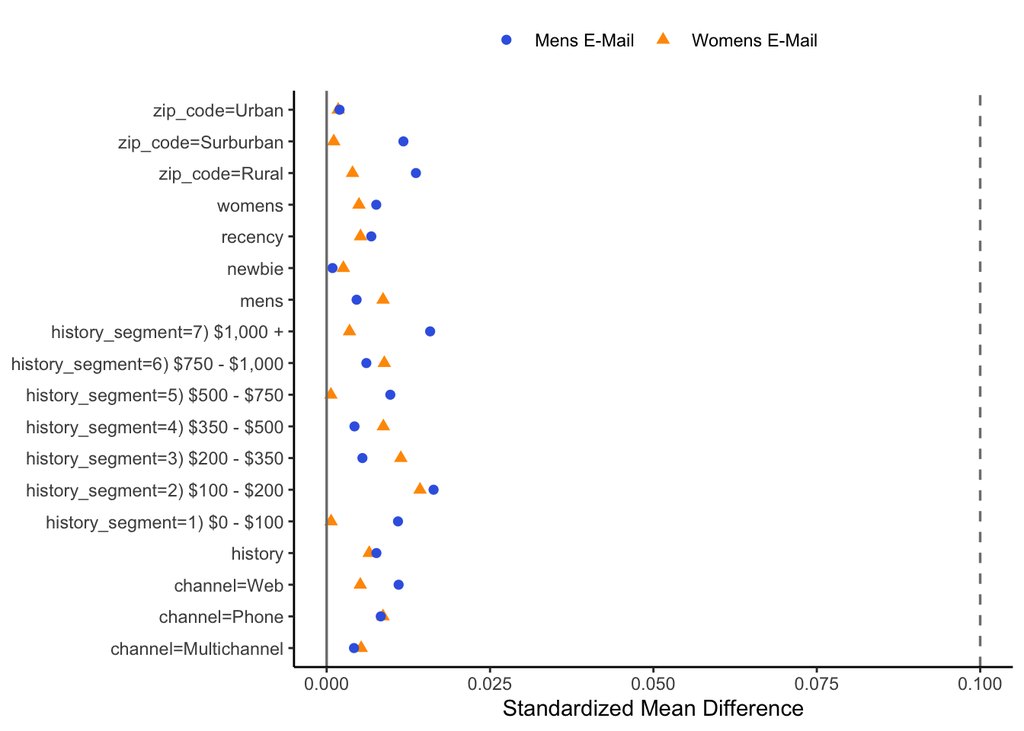

```r
smd <- sapply(c("Womens E-Mail", "Mens E-Mail"), function(a){

  x1 <- balance[d$segment == a, , drop=FALSE]
  x0 <- balance[d$segment == "No E-Mail", , drop=FALSE]

  denom <- sqrt((apply(x1, 2, var)+apply(x0, 2, var))/2)
  denom[denom == 0] <- NA_real_

  (colMeans(x1)-colMeans(x0))/denom
})

smd <- abs(smd)


library(tibble)
library(tidyr)
library(ggplot2)

smd_long <- smd |>
  as.data.frame() |>
  rownames_to_column("feature") |>
  pivot_longer(
    cols = -feature,
    names_to = "arm",
    values_to = "SMD"
  )


p <- ggplot(smd_long, aes(x = SMD, y = feature, color = arm, shape = arm)) +
  geom_point(size = 2) +
  geom_vline(xintercept = 0, linetype = "solid", color = "grey50", linewidth = 0.6) +
  geom_vline(xintercept = 0.1, linetype = "dashed", color = "grey50", linewidth = 0.6) +
  scale_color_manual(values = c("#3B66E3", "#FF9900")) +
  scale_shape_manual(values = c(16, 17)) +
  labs(x = "Standardized Mean Difference", y = NULL, color = NULL, shape = NULL) +
  theme_classic() +
  theme(legend.position = "top")



pdf("outputs/smd.pdf", width = 5.5, height = 4.5)
print(p)
dev.off()
```

## 3. Average Treatment Effects: ATE

With `conversion` as the outcome, the difference in purchase rates between an email arm and the no-email control is the unadjusted ATE in this randomized experiment. Probability differences are multiplied by 100 and expressed in *percentage points*. The analysis reports individual 95% confidence intervals and approximate simultaneous intervals for the two email-versus-control comparisons.

```r
ate <- sapply(c("Womens E-Mail", "Mens E-Mail"), function(a){

  y1 <- d$conversion[d$segment == a]
  y0 <- d$conversion[d$segment == "No E-Mail"]

  effect <- mean(y1) - mean(y0)
  se <- sqrt(var(y1) / length(y1) + var(y0) / length(y0))

  c(
    ATE_pp = 100 * effect,
    SE_pp = 100 * se,
    CI95_low_pp = 100 * (effect - 1.96 * se),
    CI95_high_pp = 100 * (effect + 1.96 * se),
    simultaneous_low_pp = 100 * (effect - 2.2414 * se),
    simultaneous_high_pp = 100 * (effect + 2.2414 * se)
  )
})

ate
```

```
##                      Womens E-Mail Mens E-Mail
## ATE_pp                  0.31110575  0.68050065
## SE_pp                   0.08226771  0.09208728
## CI95_low_pp             0.14986104  0.50000959
## CI95_high_pp            0.47235046  0.86099172
## simultaneous_low_pp     0.12671091  0.47409623
## simultaneous_high_pp    0.49550059  0.88690508
```

```r
######
```

## 4. Construct Model Inputs

`mens` and `womens` describe historical product purchases, rather than customer gender. Numerical variables and categorical indicators form $X$. The binary analysis focuses on **Womens E-Mail versus No E-Mail**; the menswear email arm is excluded from binary learner training and testing.

```r
# numeric variables
Xtrain <- as.matrix(dtrain[num_cols])
Xtest  <- as.matrix(dtest[num_cols])

for (v in cat_cols) {
  levels_v <- sort(unique(dtrain[[v]]))
  for (level in levels_v) {
    name <- paste(v, level, sep="=")
    Xtrain <- cbind(Xtrain, setNames(data.frame(as.numeric(dtrain[[v]] == level)), name))
    Xtest <- cbind(Xtest, setNames(data.frame(as.numeric(dtest[[v]] == level)), name))
  }
}

Xtrain <- as.matrix(Xtrain)
Xtest  <- as.matrix(Xtest)

storage.mode(Xtrain) <- "double"
storage.mode(Xtest)  <- "double"

binary_train <- dtrain$segment %in% c(
  "No E-Mail",
  "Womens E-Mail"
)

binary_test <- dtest$segment %in% c(
  "No E-Mail",
  "Womens E-Mail"
)

Xb_train <- Xtrain[binary_train, , drop=FALSE]
Xb_test  <- Xtest[binary_test, , drop=FALSE]

Ab_train <- as.numeric(
  dtrain$segment[binary_train] == "Womens E-Mail"
)

Ab_test <- as.numeric(
  dtest$segment[binary_test] == "Womens E-Mail"
)

Yb_train <- dtrain$conversion[binary_train]
Yb_test  <- dtest$conversion[binary_test]

table(Ab_train)
```

```
## Ab_train
##     0     1
## 17044 17109
```

```r
table(Ab_test)
```

```
## Ab_test
##    0    1
## 4262 4278
```

```r
mean(Yb_train[Ab_train == 0])
```

```
## [1] 0.005691152
```

```r
mean(Yb_train[Ab_train == 1])
```

```
## [1] 0.00853352
```

## 5. Predict Treatment Effects with S, T, X, and DR Learners

The target is the conditional average treatment effect (CATE):
$$\tau(x)=\mathbb E[Y(1)-Y(0)\mid X=x].$$

The S-learner fits a single outcome model using $X$ and treatment status. The T-learner fits separate outcome models for each arm and subtracts their predictions. The X-learner constructs imputed treatment-effect targets in each arm and combines their predictions with equal weights. The DR-learner uses outcome models and the known randomization probability $e=0.5$ to construct a pseudo-outcome, then learns its relationship with $X$.

In this implementation, the T-models used to construct the DR pseudo-outcome are fitted and evaluated on the same training sample, without cross-fitting. This is an educational DR-learner implementation and should not be equated with strictly cross-fitted DML inference. Individual causal effects are unobserved, so held-out uplift ranking and targeting performance are more relevant to evaluating these models than purchase-prediction AUC alone.

```r
library(grf)

set.seed(12345)

S_model <- regression_forest(
  cbind(Xb_train, A=Ab_train),
  Yb_train
)

X1 <- cbind(Xb_test, A=1)
X0 <- cbind(Xb_test, A=0)

S_test <- predict(S_model, X1)$predictions -
  predict(S_model, X0)$predictions

set.seed(12345)

T_model1 <- regression_forest(
  Xb_train[Ab_train == 1, , drop=FALSE],
  Yb_train[Ab_train == 1]
)

T_model0 <- regression_forest(
  Xb_train[Ab_train == 0, , drop=FALSE],
  Yb_train[Ab_train == 0]
)

T_test <- predict(T_model1, Xb_test)$predictions -
  predict(T_model0, Xb_test)$predictions

# X-learner
mu1_train <- predict(T_model1, Xb_train)$predictions
mu0_train <- predict(T_model0, Xb_train)$predictions

D1 <- Yb_train[Ab_train == 1] - mu0_train[Ab_train == 1]
D0 <- mu1_train[Ab_train == 0] - Yb_train[Ab_train == 0]

set.seed(12345)
X_model1 <- regression_forest(
  Xb_train[Ab_train == 1, , drop=FALSE],
  D1
)

X_model0 <- regression_forest(
  Xb_train[Ab_train == 0, , drop=FALSE],
  D0
)


tau1 <- predict(X_model1, Xb_test)$predictions
tau0 <- predict(X_model0, Xb_test)$predictions
X_test <- 0.5 * tau0 + 0.5 * tau1


mu1 <- predict(T_model1, Xb_train)$predictions
mu0 <- predict(T_model0, Xb_train)$predictions

e <- rep(0.5, length(Ab_train))
pseudo_DR <- mu1 - mu0 + Ab_train * (Yb_train - mu1) / e - (1 - Ab_train) * (Yb_train - mu0) / (1 - e)

set.seed(12345)

DR_model <- regression_forest(
  Xb_train,
  pseudo_DR
)

DR_test <- predict(
  DR_model,
  Xb_test
)$predictions

scores_test <- data.frame(
  S  = S_test,
  T  = T_test,
  X  = X_test,
  DR = DR_test
)

head(scores_test)
```

```
##              S           T             X           DR
## 1 0.0006355015 0.001857035 -0.0008233343 -0.002158948
## 2 0.0028597204 0.010417427  0.0059859186  0.012041056
## 3 0.0006226854 0.002263597  0.0014793112  0.001945876
## 4 0.0013859041 0.004843933  0.0006304606  0.009161572
## 5 0.0016589962 0.003720491  0.0079019964  0.000403575
## 6 0.0023635393 0.006405506  0.0206125743  0.018377831
```

```r
res <- summary(scores_test)


######


library(ggplot2)
```

## 6. Test-Set Uplift and Qini Curves

Each learner produces treatment-effect scores on the held-out test set. Customers are ranked from highest to lowest score. For the top $q$ fraction, the code computes cumulative incremental purchase probability per customer in the entire test sample:

$$G(q)=\frac{1}{n}\sum_{i\in\mathrm{top}(q)}
\left[\frac{A_iY_i}{0.5}-\frac{(1-A_i)Y_i}{0.5}\right],
\qquad
Q(q)=G(q)-qG(1).$$

The black dashed line in the uplift plot is the random-ranking reference, $qG(1)$. The centered Qini curve subtracts this reference. A larger Qini area indicates greater cumulative uplift from the ranking in this test sample, although the curves remain subject to sampling variation. Plot settings follow the original R script.

```r
grid <- seq(0, 1, length.out=101)

a <- Ab_test
y <- Yb_test

# IPW pseudo-outcome
z <- a*y/0.5 - (1-a)*y/0.5

curve_list <- list()
curve_table <- data.frame()

for (name in colnames(scores_test)) {

  score <- scores_test[[name]]

  # Sort predicted CATE from highest to lowest
  order_idx <- order(-score, method="radix")

  # cumulative IPW uplift
  cum <- c(0, cumsum(z[order_idx])) / length(z)

  # Python uses zero-based indexing, so add 1 for R
  k <- floor(grid * length(z))
  gain <- cum[k + 1]

  # centered Qini
  qini <- gain - grid * cum[length(cum)]

  # trapezoidal integration
  area <- sum(
    diff(grid) * (head(qini, -1) + tail(qini, -1)) / 2
  )

  curve_list[[name]] <- data.frame(
    fraction = grid,
    gain = 100 * gain,
    qini = 100 * qini,
    learner = name
  )

  curve_table <- rbind(
    curve_table,
    data.frame(
      learner = name,
      Qini_area = area
    )
  )
}

curves <- do.call(rbind, curve_list)

p1 <- ggplot(
  curves,
  aes(x=fraction, y=gain, color=learner)
) +
  geom_line(linewidth=1) +

  geom_abline(
    intercept=0,
    slope=100*mean(z),
    linetype="dashed",
    color="black"
  ) +

  labs(
    x="Fraction targeted",
    y="Increment per customer (pp)",
    title="IPW cumulative uplift",
    color=NULL
  ) +

  theme_classic(base_size=15) +
  theme(
    legend.position="top"
  )

pdf('outputs/qini.pdf')
print(p1)
dev.off()
```

[figure not shown]

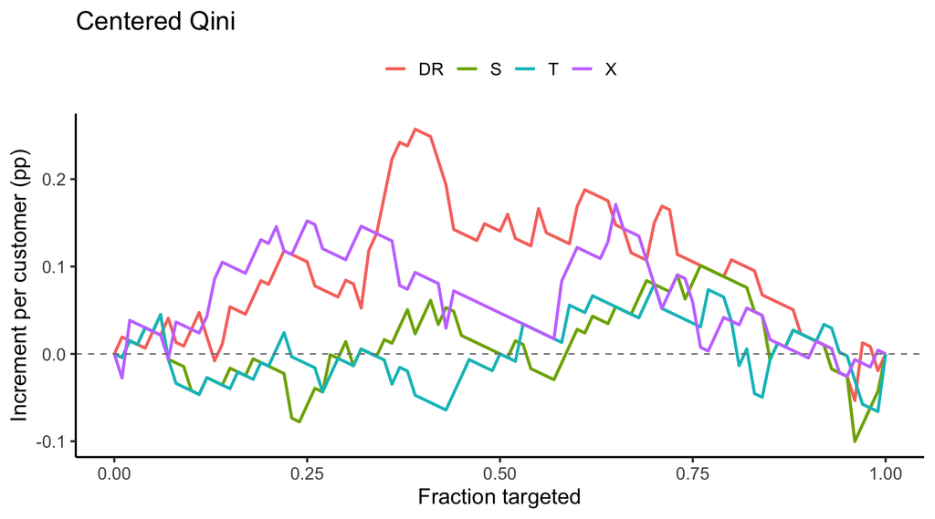

```r
p2 <- ggplot(
  curves,
  aes(x=fraction, y=qini, color=learner)
) +
  geom_line(linewidth=1) +

  geom_hline(
    yintercept=0,
    linetype="dashed",
    color="grey50"
  ) +

  labs(
    x="Fraction targeted",
    y="Increment per customer (pp)",
    title="Centered Qini",
    color=NULL
  ) +

  theme_classic(base_size=15) +
  theme(
    legend.position="top"
  )

pdf('outputs/cen_qini.pdf')
print(p2)
dev.off()
```